# Machine Learning I - Regression - Presentation

- Mateusz Domaradzki & Karol Ziolo

[figure not shown]

# Regression

## Data Preparation

### General outlook on data

I read in the data

```r
data <- read.csv("Regression/traffic_train.csv")
```

I check if there are duplicates or NAs

```r
colSums(is.na(data)) %>%
  sort()
```

```
##           date_time     weather_general    weather_detailed clouds_coverage_pct
##                   0                   0                   0                   0
##         temperature             rain_mm             snow_mm             traffic
##                   0                   0                   0                   0
```

```r
data[which(duplicated(data)),]
```

```
##                 date_time weather_general weather_detailed clouds_coverage_pct
## 28795 2018-12-02 09:00:00            Mist             mist                  90
## 28796 2018-12-02 09:00:00            Snow       light snow                  90
##       temperature rain_mm snow_mm traffic
## 28795         0.6       0       0    2331
## 28796         0.6       0       0    2334
```

Not really so we can move forward and check pattern in time

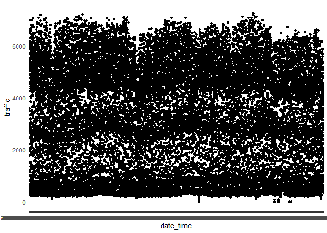

### Time preparation

I extract the most interesting part of date-time

```r
data$date_time <- as.POSIXct(data$date_time, format = "%Y-%m-%d %H:%M:%S")
yq <- as.yearqtr(data$date_time, format = "%Y-%m-%d %H:%M:%S")
data$kwartal<-format(yq, format = "%q")
data$kwartal<- as.factor(data$kwartal)
data$hour<-format(data$date_time, format='%H')
data$month<-format(data$date_time, format='%m')
data$day<-weekdays(data$date_time)
```

I apply a function to transform hours to parts of the day according to the plot given below. It’s also logical and even based in life that people are trying to commute to home in different hours. The best feeling is driving a car in an empty city at 3 am

```r
time_of_the_day<-function(x) {
  result<-list()
  if(x>=6 & x<=8){
    result<-"Traffic_morning_peak_hour"
  }
  else if(x>8 & x<15){
    result<-"Working_hours"}
  else if(x>=15 & x<=17){
    result<-"Traffic_evening_peak_hour"}
  else{
    result <-"night"}
  return(result)
}
```

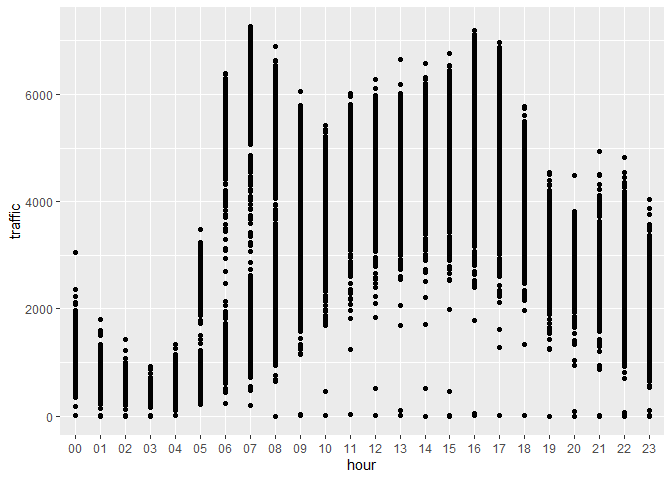

let’s apply the function

```r
data$hour2<-lapply(data$hour,time_of_the_day)
data$hour2<-as.character(data$hour2)
data$hour2<- as.factor(data$hour2)
```

### Weather preparation

I have to admit that we decided to not use this more rich in description weather column because we saw many things that we have to merge and diversity provided in weather_general is good enough to judge what should happen with the traffic. At all not every weather state should affect traffic so we just drop it instantly

```r
kable(table(data$weather_general)) %>%
  sort(decreasing = FALSE)
```

```
##  [1] "|:------------|-----:|" "|Clear        |  8030|" "|Clouds       | 10163|"
##  [4] "|Drizzle      |   919|" "|Fog          |   481|" "|Haze         |   743|"
##  [7] "|Mist         |  3491|" "|Rain         |  3559|" "|Smoke        |    17|"
## [10] "|Snow         |  1794|" "|Squall       |     4|" "|Thunderstorm |   497|"
## [13] "|Var1         |  Freq|"
```

I decided to merge some of them because logicaly there are the same and should not affect our traffic. Of course we can check if the values are different by filtering the data but it may results in overfitting the model. Let’s keep it simple

Things that should be merged in my opinion:

Smoke and Haze

Squall and Thunderstorm

```r
data$weather_general <- as.factor(data$weather_general)

data$weather_general[data$weather_general == "Maze"] <- "Fog"
data$weather_general[data$weather_general == "Haze"] <- "Smoke"
data$weather_general[data$weather_general == "Squall"] <- "Thunderstorm"

data$weather_general <- droplevels(data$weather_general)
kable(table(data$weather_general))
```

| Var1 | Freq |
| --- | --- |
| Clear | 8030 |
| Clouds | 10163 |
| Drizzle | 919 |
| Fog | 481 |
| Mist | 3491 |
| Rain | 3559 |
| Smoke | 760 |
| Snow | 1794 |
| Thunderstorm | 501 |

We won’t also use snow nor rain because those things are pretty always equal to 0

```r
kable(head(table(data$snow_mm),10))
```

| Var1 | Freq |
| --- | --- |
| 0 | 29635 |
| 0.05 | 14 |
| 0.06 | 12 |
| 0.08 | 2 |
| 0.1 | 6 |
| 0.13 | 6 |
| 0.17 | 3 |
| 0.21 | 1 |
| 0.25 | 6 |
| 0.32 | 5 |

```r
kable(head(table(data$rain_mm),10))
```

| Var1 | Freq |
| --- | --- |
| 0 | 26944 |
| 0.25 | 679 |
| 0.26 | 2 |
| 0.27 | 5 |
| 0.28 | 19 |
| 0.29 | 4 |
| 0.3 | 119 |
| 0.31 | 2 |
| 0.32 | 12 |
| 0.33 | 1 |

Lets check temperature

```r
kable(head(table(data$temperature),10))
```

| Var1 | Freq |
| --- | --- |
| -273.1 | 10 |
| -29.8 | 1 |
| -29.5 | 1 |
| -28.9 | 1 |
| -28.3 | 4 |
| -27.5 | 1 |
| -27.4 | 3 |
| -27.1 | 1 |
| -27 | 1 |
| -26.9 | 1 |

```r
data<-data[-c(which(data$temperature==-273.1)),]
data<-data[-c(which(data$rain_mm>100)),]
```

Data seems to be various but we have some outliers (at least I dont believe that we can achieve -273.1. Also I dropped an outlier from rain (I believe that is an ouliter)

### Feature selection

We also need to check if the data is at least correlated to traffic

|  | clouds_coverage_pct | temperature | rain_mm | snow_mm | traffic |
| --- | --- | --- | --- | --- | --- |
| clouds_coverage_pct | 1.0000000 | -0.1703894 | 0.0886892 | 0.0351593 | 0.0393405 |
| temperature | -0.1703894 | 1.0000000 | 0.1027189 | -0.0250283 | 0.1344646 |
| rain_mm | 0.0886892 | 0.1027189 | 1.0000000 | 0.0002111 | -0.0302496 |
| snow_mm | 0.0351593 | -0.0250283 | 0.0002111 | 1.0000000 | 0.0014836 |
| traffic | 0.0393405 | 0.1344646 | -0.0302496 | 0.0014836 | 1.0000000 |

Now im sure that I won’t use nor rain nor snow nor covarage

Also ANOVA for categorical values

|  | x |
| --- | --- |
| hour2 | 5652.41041 |
| weather_general | 49.88013 |
| kwartal | 22.20645 |

A lot of can be improved

some ggplots to improve dataset

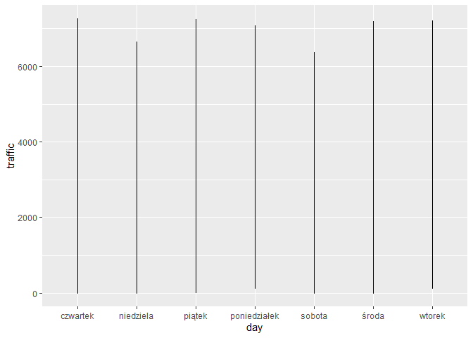

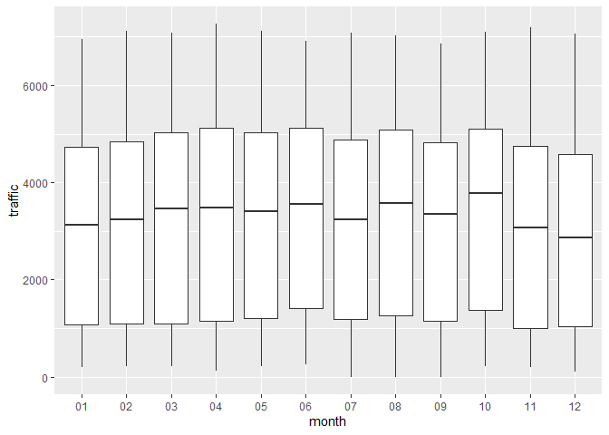

By that we will create 2 functions to divide months and days into useful parts

```r
season_of_the_year <- function(x) {
  result<-list()
  if(x=='11' || x=='12' || x=='01'){
    result<-"Winter"
  }
  else if(x=='07' || x=='08' || x=='09' ){
    result<-"Summer_Holidays"}
  else{
    result <-"The_Rest_of_the_season"}
  return(result)
}

day_of_the_wk<- function(x) {
  result<-list()
  if(x=='sobota' || x=='niedziela'){
    result<-"Weekend"
  }
  else{
    result <-"Working_day"}
  return(result)
}

data$season<-lapply(data$month,season_of_the_year)
data$season<-as.character(data$season)
data$season<-as.factor(data$season)

data$day2<-lapply(data$day, day_of_the_wk)
data$day2<-as.character(data$day2)
data$day2<-as.factor(data$day2)
```

last ANOVA to check if we are in a better position

|  | x |
| --- | --- |
| hour2 | 5652.41041 |
| day2 | 1596.66607 |
| season | 60.38177 |
| weather_general | 49.88013 |
| kwartal | 22.20645 |

That’s seems like a success so I go to proceed some algorithms

Our final dataset:

```r
data_final<-data[,c(8,2,5,13,14,15)]
kable(head(data_final,20))
```

| traffic | weather_general | temperature | hour2 | season | day2 |
| --- | --- | --- | --- | --- | --- |
| 508 | Clear | 11.5 | night | The_Rest_of_the_season | Working_day |
| 323 | Clear | 10.3 | night | The_Rest_of_the_season | Working_day |
| 274 | Clear | 8.0 | night | The_Rest_of_the_season | Working_day |
| 372 | Clear | 7.9 | night | The_Rest_of_the_season | Working_day |
| 812 | Clear | 6.4 | night | The_Rest_of_the_season | Working_day |
| 2720 | Clear | 5.5 | night | The_Rest_of_the_season | Working_day |
| 5674 | Clear | 5.1 | night | The_Rest_of_the_season | Working_day |
| 6512 | Clear | 5.0 | night | The_Rest_of_the_season | Working_day |
| 5473 | Clear | 9.3 | night | The_Rest_of_the_season | Working_day |
| 5096 | Clear | 18.8 | night | The_Rest_of_the_season | Working_day |
| 4887 | Clear | 20.1 | night | The_Rest_of_the_season | Working_day |
| 5335 | Clear | 21.2 | night | The_Rest_of_the_season | Working_day |
| 5699 | Clear | 22.0 | Traffic_evening_peak_hour | The_Rest_of_the_season | Working_day |
| 6130 | Clear | 22.0 | Traffic_evening_peak_hour | The_Rest_of_the_season | Working_day |
| 4620 | Clouds | 20.5 | night | The_Rest_of_the_season | Working_day |
| 3594 | Clouds | 17.5 | night | The_Rest_of_the_season | Working_day |
| 2895 | Clouds | 15.0 | night | The_Rest_of_the_season | Working_day |
| 2643 | Clear | 14.0 | night | The_Rest_of_the_season | Working_day |
| 1783 | Clear | 13.1 | night | The_Rest_of_the_season | Working_day |
| 1017 | Clear | 12.1 | night | The_Rest_of_the_season | Working_day |

## Algorithms

- OLS
- LASSO
- RIDGE
- Elastic approach between them
- KNN
- SVR

**Due to computational issues I decided to present only final parameteres for every selected algorithm. I checked a range values of K for KNN etc but including for example more possibilities for SVR would kill my computer**

We will try to check both ends, I mean high variance and low bias plus low variance and high bias then we will use linear regression + Lasso/Ridge. Then we have two imporant efficient algorithms KNN which is one of the most optimal accoring to books and SVR which is also very sufficient especially if we have weird combinations in dataset

### Linear regression

setting the right options

I will try 2 models, one clear and one with interactions between variables. I’ve been doing some experiments with them and which are the best so below I will show only the best interactions I could find and that are logical for me

```r
#model without interactions
traffic_lm <- lm(traffic~. -1,
                 data = data_final)

summary(traffic_lm)
```

```
##
## Call:
## lm(formula = traffic ~ . - 1, data = data_final)
##
## Residuals:
##     Min      1Q  Median      3Q     Max
## -4911.8 -1402.5    41.6  1445.7  4427.3
##
## Coefficients:
##                                Estimate Std. Error t value Pr(>|t|)
## weather_generalClear           1734.785     36.742  47.216  < 2e-16 ***
## weather_generalClouds          1998.959     37.944  52.682  < 2e-16 ***
## weather_generalDrizzle         1769.942     68.043  26.012  < 2e-16 ***
## weather_generalFog             1556.417     85.940  18.111  < 2e-16 ***
## weather_generalMist            1663.915     45.189  36.821  < 2e-16 ***
## weather_generalRain            1744.106     45.784  38.094  < 2e-16 ***
## weather_generalSmoke           2250.029     71.794  31.340  < 2e-16 ***
## weather_generalSnow            1863.488     53.915  34.563  < 2e-16 ***
## weather_generalThunderstorm    1392.242     85.219  16.337  < 2e-16 ***
## temperature                      22.893      1.147  19.953  < 2e-16 ***
## hour2Traffic_evening_peak_hour 2317.681     31.399  73.813  < 2e-16 ***
## seasonThe_Rest_of_the_season    332.376     29.283  11.351  < 2e-16 ***
## seasonWinter                    292.033     39.627   7.369 1.76e-13 ***
## day2Working_day                 987.993     22.428  44.052  < 2e-16 ***
## ---
## Signif. codes:  0 '***' 0.001 '**' 0.01 '*' 0.05 '.' 0.1 ' ' 1
##
## Residual standard error: 1744 on 29673 degrees of freedom
## Multiple R-squared:  0.7885, Adjusted R-squared:  0.7884
## F-statistic:  7904 on 14 and 29673 DF,  p-value: < 2.2e-16
```

```r
#model with interactions
traffic_lm2 <- lm(traffic~. + weather_general*hour2  + day2*hour2 + weather_general*day2 -1, # best formula
                 data = data_final)
summary(traffic_lm2)
```

```
##
## Call:
## lm(formula = traffic ~ . + weather_general * hour2 + day2 * hour2 +
##     weather_general * day2 - 1, data = data_final)
##
## Residuals:
##     Min      1Q  Median      3Q     Max
## -4415.4 -1411.2    34.4  1442.6  4526.8
##
## Coefficients:
##                                                            Estimate Std. Error
## weather_generalClear                                       1892.641     44.577
## weather_generalClouds                                      2130.941     45.385
## weather_generalDrizzle                                     1845.135    117.212
## weather_generalFog                                         1121.575    143.798
## weather_generalMist                                        1530.677     63.193
## weather_generalRain                                        1753.733     65.920
## weather_generalSmoke                                       2085.923    123.648
## weather_generalSnow                                        1926.640     86.537
## weather_generalThunderstorm                                1104.823    138.808
## temperature                                                  23.066      1.148
## hour2Traffic_evening_peak_hour                             1960.609     79.509
## seasonThe_Rest_of_the_season                                330.650     29.222
## seasonWinter                                                294.128     39.552
## day2Working_day                                             736.169     42.930
## weather_generalClouds:hour2Traffic_evening_peak_hour       -276.044     79.268
## weather_generalDrizzle:hour2Traffic_evening_peak_hour        36.089    181.647
## weather_generalFog:hour2Traffic_evening_peak_hour          -725.057    402.884
## weather_generalMist:hour2Traffic_evening_peak_hour          -45.670    131.054
## weather_generalRain:hour2Traffic_evening_peak_hour          -54.000    107.048
## weather_generalSmoke:hour2Traffic_evening_peak_hour        -552.226    187.054
## weather_generalSnow:hour2Traffic_evening_peak_hour         -295.007    145.793
## weather_generalThunderstorm:hour2Traffic_evening_peak_hour   10.510    276.394
## hour2Traffic_evening_peak_hour:day2Working_day              728.934     68.645
## weather_generalClouds:day2Working_day                        89.838     57.372
## weather_generalDrizzle:day2Working_day                      113.515    135.426
## weather_generalFog:day2Working_day                          918.116    175.789
## weather_generalMist:day2Working_day                         429.810     77.452
## weather_generalRain:day2Working_day                         217.306     78.338
## weather_generalSmoke:day2Working_day                        574.414    144.680
```

[output cut: 25 more lines]

```
## hour2Traffic_evening_peak_hour:day2Working_day              10.619  < 2e-16 ***
## weather_generalClouds:day2Working_day                        1.566 0.117387
## weather_generalDrizzle:day2Working_day                       0.838 0.401922
## weather_generalFog:day2Working_day                           5.223 1.77e-07 ***
## weather_generalMist:day2Working_day                          5.549 2.89e-08 ***
## weather_generalRain:day2Working_day                          2.774 0.005542 **
## weather_generalSmoke:day2Working_day                         3.970 7.20e-05 ***
## weather_generalSnow:day2Working_day                          1.757 0.078947 .
## weather_generalThunderstorm:day2Working_day                  3.973 7.12e-05 ***
## ---
## Signif. codes:  0 '***' 0.001 '**' 0.01 '*' 0.05 '.' 0.1 ' ' 1
##
## Residual standard error: 1739 on 29656 degrees of freedom
## Multiple R-squared:   0.79,  Adjusted R-squared:  0.7898
## F-statistic:  3598 on 31 and 29656 DF,  p-value: < 2.2e-16
```

```r
traffic_predicted <- predict(traffic_lm)
traffic_predicted2 <- predict(traffic_lm2)
```

let’s plot real vs predicted values

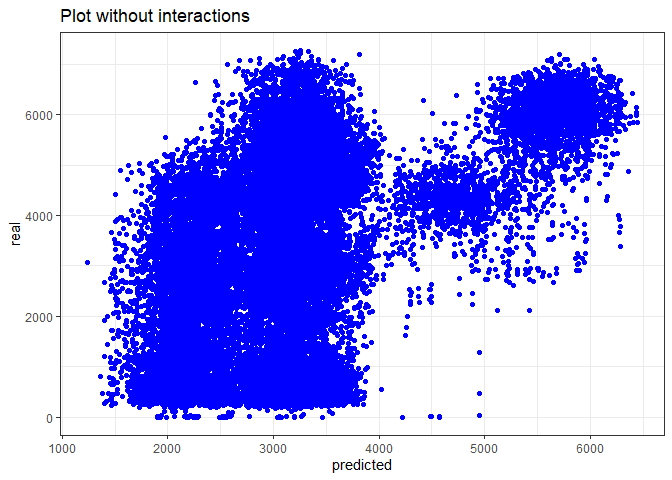

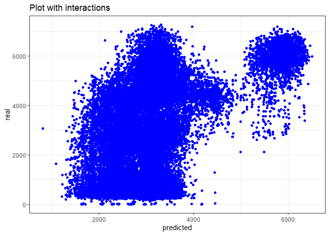

### Lasso/Ridge/Elastic approach

The good thing about lasso/Ridge is that we can apply both of them to erase non important values and set aplha at a certain level to chose which one we would love to use. This method is at the other end of bias/variance trade plot

#### Ridge

lets start with ridge regression

```r
ctrl_cv5 <- trainControl(method = "cv",
                         number = 5) ## cross-validation


parameters_ridge <- expand.grid(alpha = 0,
                                lambda = seq(0, 1e3, 1))

traffic_ridge <- train(traffic~. + weather_general*hour2  + day2*hour2 + weather_general*day2 -1,
                       data = data_final,
                       method = "glmnet",
                       tuneGrid = parameters_ridge,
                       trControl = ctrl_cv5)

traffic_ridge$bestTune
```

```
##    alpha lambda
## 80     0     79
```

Lamba is equals 79 so really close to the linear regression. Lets check LASSO -> RMSE about 1740

```r
parameters_lasso <- expand.grid(alpha = 1,
                                lambda = seq(1, 1e4, 10))

traffic_lasso<- train(traffic~. + weather_general*hour2  + day2*hour2 + weather_general*day2 -1,
                      data = data_final,
                      method = "glmnet",
                      tuneGrid = parameters_lasso,
                      trControl = ctrl_cv5)
traffic_lasso$bestTune
```

```
##   alpha lambda
## 1     1      1
```

lambda and alfa equals to 1, very interesting to be honest

Let’s check the elastic approach in Alpha

```r
set.seed(2137) ## Let's set seed because lambda and alfa may vary but there are both really similar, just to keep it constant
parameters_elastic2 <- expand.grid(alpha = seq(0, 1, 0.2),
                                   lambda = seq(0, 10, 0.1))

traffic_elastic <- train(traffic~. + weather_general*hour2  + day2*hour2 + weather_general*day2,
                         data = data_final,
                         method = "glmnet",
                         tuneGrid = parameters_elastic2,
                         trControl = ctrl_cv5)


traffic_elastic$bestTune
```

```
##     alpha lambda
## 122   0.2      2
```

So we may be quite sure that between those 3 algorithms we are going to the next point with an elastic approach and alpha=0.2 with lambda = 2

[figure not shown]

### KNN

I decided to use this algorithm because in my books on Machine Learning they say this algorithm may be the most accurate one in many cases. What I mean, we don’t really use any presumptions and we only match something because of neighbours. In this case, when it’s hard for my data to fit in any kind of regression that assume for example normal distribution, or try to fit to data any coefficients this one may be really relevant player. We will see at the end in the comparison!

Once again i experimented between different values of K for KNN and I decided to go with 19

```r
ctrl_cv5 <- trainControl(method = "cv",
                         number = 5)

k_possible <-data.frame(k=19) ## The value 19 is the best for our dataset so im gonna go with it

traffic_knn <-
  train(traffic~. + weather_general*hour2  + day2*hour2 + weather_general*day2,
        data = data_final,
        method = "knn",
        trControl = ctrl_cv5,
        tuneGrid = k_possible,
        preProcess = c("range"))

## k=19 is the lowest RMSE we can obtain, So I will go with that.
```

let’s plot it

[output not shown]

[output cut: 365 more lines]

[output not shown]

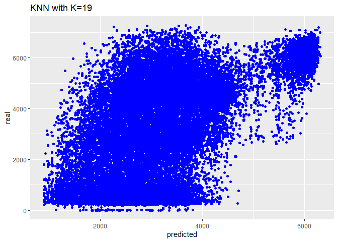

### SVR

I would like to start with a point that my laptop is kinda slow and I didn’t menage to estimate any combination of sigma and C on a full dataset. So I drew a sample of 10% observations and then adjusted my sigma and C. Therefore this would be the most optimal algorithm but I don’t have a possibility to check it. Thus, below I present the best possible algorithm I could estimate on a random sample. Then of course I checked that on a biggest sample (around 30% of observations) and couple times on a full dataset. But most estimations were conducted on small samples

```r
parametersC_sigma2 <-
  expand.grid(C = 415,
              sigma = 0.1)


svm_Radial2 <- train(traffic~. + weather_general*hour2  + day2*hour2 + weather_general*day2,
                            data = data_final,
                            method = "svmRadial",
                            tuneGrid = parametersC_sigma2,
                            trControl = ctrl_cv5)
svm_Radial2
```

```
## Support Vector Machines with Radial Basis Function Kernel
##
## 29687 samples
##     5 predictor
##
## No pre-processing
## Resampling: Cross-Validated (5 fold)
## Summary of sample sizes: 23750, 23751, 23748, 23750, 23749
## Resampling results:
##
##   RMSE      Rsquared   MAE
##   1754.957  0.2323844  1435.961
##
## Tuning parameter 'sigma' was held constant at a value of 0.1
## Tuning
##  parameter 'C' was held constant at a value of 415
```

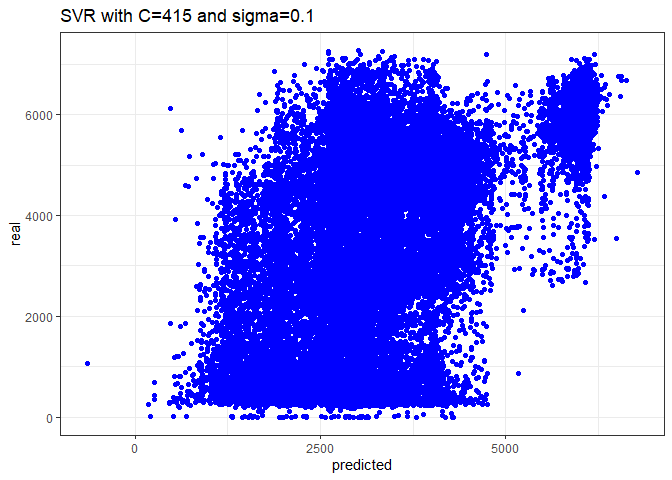

## MAPE between all algorithms

I wrote a function to check it for me

First im gonna create a data frame with our predictions

```r
predicted_ols <- predict(traffic_lm, data_final)
predicted_lasso_ridge <- predict(traffic_elastic , data_final)
predicted_svr <- predict(svm_Radial2 , data_final)
predicted_knn <- predict(traffic_knn, data_final)

predictions<-data.frame(predicted_ols,predicted_lasso_ridge,predicted_svr,predicted_knn)

MAPE<-matrix(8,nrow=2,ncol=4)
```

then let’s create a function that will judge for us and return the best option

```r
for(i in 1:length(predictions))
{
  MAPE[1,i] <-colnames(predictions[i])
  MAPE[2,i] <-MAPE(unlist(predictions[i]), data_final$traffic+1)
  if(i==length(predictions))
  {
    print(paste0('The best algorithm for our dataset is ', substr(MAPE[1,which(MAPE[2,]==min(MAPE))],11,20), ' with the predicted MAPE equals to ',
           round(as.numeric(min(MAPE)),2),'%'))

  }
}
```

```
## [1] "The best algorithm for our dataset is knn with the predicted MAPE equals to 3.24%"
```

```r
kable(MAPE)
```

| predicted_ols | predicted_lasso_ridge | predicted_svr | predicted_knn |
| --- | --- | --- | --- |
| 3.47050073877648 | 3.41662626111629 | 3.28266342056404 | 3.23502440338716 |

So at the end I can only say that our book to Machine Learning was quite right in a judge that KNN is very often a most optimal alogirhtm. Definitely im gonna finish this book during our summer break

# Classification

## Data Exploration

### General outlook on data

Let read the data.

```r
data2 = read.csv("Classification/drugs_train.csv")
```

My first step was to check for NAs.

```r
kable(colSums(is.na(data2)) %>%
  sort())
```

|  | x |
| --- | --- |
| id | 0 |
| age | 0 |
| gender | 0 |
| education | 0 |
| country | 0 |
| ethnicity | 0 |
| personality_neuroticism | 0 |
| personality_extraversion | 0 |
| personality_openness | 0 |
| personality_agreeableness | 0 |
| personality_conscientiousness | 0 |
| personality_impulsiveness | 0 |
| personality_sensation | 0 |
| consumption_alcohol | 0 |
| consumption_amphetamines | 0 |
| consumption_caffeine | 0 |
| consumption_cannabis | 0 |
| consumption_chocolate | 0 |
| consumption_mushrooms | 0 |
| consumption_nicotine | 0 |
| consumption_cocaine_last_month | 0 |

We do not have any NAs thus we can move forward and check which variables are characters.

```r
kable(sapply(data2, is.character))
```

|  | x |
| --- | --- |
| id | TRUE |
| age | TRUE |
| gender | TRUE |
| education | TRUE |
| country | TRUE |
| ethnicity | TRUE |
| personality_neuroticism | FALSE |
| personality_extraversion | FALSE |
| personality_openness | FALSE |
| personality_agreeableness | FALSE |
| personality_conscientiousness | FALSE |
| personality_impulsiveness | FALSE |
| personality_sensation | FALSE |
| consumption_alcohol | TRUE |
| consumption_amphetamines | TRUE |
| consumption_caffeine | TRUE |
| consumption_cannabis | TRUE |
| consumption_chocolate | TRUE |
| consumption_mushrooms | TRUE |
| consumption_nicotine | TRUE |
| consumption_cocaine_last_month | TRUE |

```r
data2 = data2[,-1]
```

We have noticed that there is an ID column which we decided to drop because it is not valuable for us.

### Age

As it is presented below people were divided into six age groups. However, we have noticed that its distribution is slightly imbalanced. Thus, we decided to merge groups “55-64” and “65+” into one group called “55+” to be more representative.

```r
kable(table(data2$age))
```

| Var1 | Freq |
| --- | --- |
| 18-24 | 528 |
| 25-34 | 375 |
| 35-44 | 278 |
| 45-54 | 233 |
| 55-64 | 72 |
| 65+ | 14 |

```r
data2$age[data2$age=="55-64"] <- "55+"
data2$age[data2$age == "65+"] <- "55+"

data2$age = factor(data2$age, levels = c("18-24",
                                         "25-34",
                                         "35-44",
                                         "45-54",
                                         "55+"),ordered = TRUE)

data2$age <- droplevels(data2$age)
```

### Gender

As of Gender variable we modified it into factors.

```r
data2$gender = factor(data2$gender, levels = c("male","female"), ordered = TRUE)
```

### Education

The education variable is divided into many levels, which again is not distributed evenly. We have many disproportions so we decided to merge people who left school at or before 18 into one group.

```r
kable(table(data2$education))
```

| Var1 | Freq |
| --- | --- |
| Doctorate degree | 66 |
| Left school at 16 years | 72 |
| Left school at 17 years | 26 |
| Left school at 18 years | 85 |
| Left school before 16 years | 20 |
| Masters degree | 229 |
| Professional certificate/ diploma | 221 |
| Some college or university, no certificate or degree | 405 |
| University degree | 376 |

```r
data2$education[data2$education %in% c("Left school before 16 years",
                                       "Left school at 16 years",
                                       "Left school at 17 years",
                                       "Left school at 18 years")] <- "Left school at or before 18"

data2$education = factor(data2$education, levels = c("Left school at or before 18",
                                                     "Some college or university, no certificate or degree",
                                                     "Professional certificate/ diploma",
                                                     "University degree",
                                                     "Masters degree",
                                                     "Doctorate degree"),
                         ordered = TRUE)
data2$education <- droplevels(data2$education)
```

### Country

As for the country variable we have noticed that most people are from Australia or USA. However, there is small number of people from Canada and Ireland so we decided to assign them to the group of others.

```r
kable(table(data2$country))
```

| Var1 | Freq |
| --- | --- |
| Australia | 460 |
| Canada | 5 |
| Ireland | 13 |
| New Zealand | 94 |
| Other | 44 |
| UK | 73 |
| USA | 811 |

```r
data2$country[data2$country %in% c("Canada","Ireland")] <- "Other"
```

### Ethnicity

We checked the Ethnicity variable and we have noticed that sample is practically homogeneous. Thus, we decided to drop it because it does not provide any reliable information regarding other ethnic groups.

```r
kable(table(data2$ethnicity))
```

| Var1 | Freq |
| --- | --- |
| Asian | 25 |
| Black | 22 |
| Mixed-Black/Asian | 1372 |
| Mixed-White/Asian | 15 |
| Mixed-White/Black | 47 |
| Other | 16 |
| White | 3 |

```r
data2 = data2[,-5]
```

### Consumption

We believe that variables that concern consumption should be grouped because the frequency split is too broad. It was decided to downgrade it into three groups: “regularly”, “occasionally” and “never”. We also consider that “Consumption Chocolate” and “Consumption Caffeine” do not have any direct impact whether person consumes cocaine so we decided to drop them from our dataset.

```r
# Vector of consumption variables which concern us
consumption_variables = c("consumption_alcohol", "consumption_amphetamines",
                          "consumption_cannabis", "consumption_mushrooms",
                          "consumption_nicotine")
# Grouping function
fun =
  function(x){
  if (x %in% c("never used","used over a decade ago","used in last decade")){
    x = "never"}
  else if (x %in% c("used in last year","used in last month")){
    x = "occasionally"}
  else if (x %in% c("used in last week","used in last day")){
    x = "regularly"}
  }

# Applying grouping function
data2[consumption_variables] = unlist(lapply(data2[consumption_variables], function(y) lapply(y, fun)))

# Modifying into factors
data2[consumption_variables] = lapply(data2[consumption_variables],
                                     function(x) factor(x, levels = c("never","occasionally","regularly"),ordered = TRUE))

# Dropping "Consumption Chocolate" and "Consumption Caffeine" variables
data2 = data2[,-c(14,16)]
```

### Personality Variables

Firstly, we decided to check whether personality variables have any outliers. To do that we looked at their ranges. Based on the table below we can establish that we do not have outliers.

```r
min_max = matrix(1:14,nrow = 7, ncol = 2)
colnames(min_max) = c("Minimum", "Maximum")
rownames(min_max) = names(which(sapply(data2,is.numeric)))
min_max[,1] = apply(data2[names(which(sapply(data2,is.numeric)))],2, min)
min_max[,2] = apply(data2[names(which(sapply(data2,is.numeric)))],2, max)
kable(min_max)
```

|  | Minimum | Maximum |
| --- | --- | --- |
| personality_neuroticism | 0 | 100 |
| personality_extraversion | 0 | 100 |
| personality_openness | 0 | 100 |
| personality_agreeableness | 0 | 100 |
| personality_conscientiousness | 0 | 100 |
| personality_impulsiveness | 0 | 100 |
| personality_sensation | 0 | 100 |

Knowing the fact that we do not have any irregularities we decided to aggregate this variables and create one called “personality”. It aims to present the dominant character traits. The reason behind this decision is that we believe that these variables in continuous form are not reliable because people cannot establish real level of their personality traits. What it might be valuable from that data is its hierarchical order. So, we decided to check which personality trait had the highest score and we assigned it to personality variable.

```r
data2["personality"] =
  colnames(data2[sapply(data2,is.numeric)])[apply(data2[sapply(data2,is.numeric)],1,which.max)]

data2$personality = as.factor(data2$personality)
```

### Dependent Variable

We modified our dependent variable into factor. We also noticed that our dataset is strongly imbalanced. Thus, we decided to use upsampling in our analysis.

```r
kable(table(data2$consumption_cocaine_last_month))
```

| Var1 | Freq |
| --- | --- |
| No | 1373 |
| Yes | 127 |

```r
data2$consumption_cocaine_last_month = factor(data2$consumption_cocaine_last_month, levels = c("No","Yes"), ordered = TRUE)

data2 = data2[sapply(data2,is.factor)]
```

### Statistical Tests

To verify whether variables has a significant impact on cocaine consumption, we decided to run chi-squred tests. Based on the results we decided to drop the education variable because its p-value exceeded 5%.

```r
chisqr = matrix(1:10,nrow = 10, ncol = 1)
colnames(chisqr) = c("p-value")
rownames(chisqr) = names(which(sapply(data2,is.factor)))
chisqr[,1] = apply(data2[names(which(sapply(data2,is.factor)))],2,
                   function(x) round(chisq.test(x, data2$consumption_cocaine_last_month,correct=FALSE)$p.value,4))
kable(chisqr)
```

|  | p-value |
| --- | --- |
| age | 0.0000 |
| gender | 0.0003 |
| education | 0.0736 |
| consumption_alcohol | 0.0040 |
| consumption_amphetamines | 0.0000 |
| consumption_cannabis | 0.0000 |
| consumption_mushrooms | 0.0000 |
| consumption_nicotine | 0.0000 |
| consumption_cocaine_last_month | 0.0000 |
| personality | 0.0000 |

```r
data2 = data2[,-3]
data2$education
```

## Data Modelling

### Algorithms

We decided that we are going to try to use 4 algorithms that are presented below:

- Logistic Regression
- KNN
- SVM
- Random Forest

Each of the presented algorithms has its own benefits and drawbacks and this is the reason why we decided to go with all of them. We wanted to compare them and choose the most accurate for this dataset.

### Cross-Validation

Overfitting is one of the burdensome issue in Machine Learning. As we want to perform as accurate model as possible we needed to minimize that problem, so we decided to apply a Cross Validation procedure. Even though it is computationally expensive, we do not waste too much data which is extremely important in our case. Ultimately, we decided to go with five folds and three repeats. Additionally, as it was previously said, we used upsampling method.

```r
options(contrasts = c("contr.treatment",  # for non-ordinal factors
                      "contr.treatment")) # for ordinal factors
set.seed(9432398) # We specify random seed

# Train control with cross-validation
ctrl_cv5 <- trainControl(method = "repeatedcv",
                         number = 5,
                         classProbs = TRUE,
                         summaryFunction = twoClassSummary,
                         repeats = 3)

ctrl_cv5$sampling = "up"
```

### Logistic regression

```r
data2_logit_train1 <-
  train(consumption_cocaine_last_month ~ . + personality*consumption_amphetamines
        + personality*consumption_cannabis + personality*consumption_cannabis,
        data = data2,
        method = "glm",
        family = "binomial",
        metric = "ROC",
        trControl = ctrl_cv5)
data2_logit_train1
```

```
## Generalized Linear Model
##
## 1500 samples
##    8 predictor
##    2 classes: 'No', 'Yes'
##
## No pre-processing
## Resampling: Cross-Validated (5 fold, repeated 3 times)
## Summary of sample sizes: 1200, 1200, 1201, 1199, 1200, 1200, ...
## Addtional sampling using up-sampling
##
## Resampling results:
##
##   ROC        Sens       Spec
##   0.7395105  0.7263959  0.6876923
```

```r
data2_logit_train1 <-
  train(consumption_cocaine_last_month ~ .,
        data = data2,
        method = "glm",
        family = "binomial",
        metric = "ROC",
        trControl = ctrl_cv5)

data2_logit_train1
```

```
## Generalized Linear Model
##
## 1500 samples
##    8 predictor
##    2 classes: 'No', 'Yes'
##
## No pre-processing
## Resampling: Cross-Validated (5 fold, repeated 3 times)
## Summary of sample sizes: 1200, 1199, 1200, 1201, 1200, 1199, ...
## Addtional sampling using up-sampling
##
## Resampling results:
##
##   ROC       Sens       Spec
##   0.786158  0.7319779  0.7322051
```

### KNN

One of the biggest advantage of the KNN algorithm is its simplicity. It is quite intuitive method which simply finds K nearest neighbors. Unfortunately, this algorithm is vulnerable to uneven distribution of the explained variable. We believe that upsampling procedure we used might solve that problem.

```r
k_possible = data.frame(k=seq(1,20,1))

data2_knn_train <-
  train(consumption_cocaine_last_month ~ .,
        data2,
        method = "knn",
        metric = "ROC",
        trControl = ctrl_cv5,
        tuneGrid = k_possible,
        preProcess = c("range"))

data2_knn_train
```

```
## k-Nearest Neighbors
##
## 1500 samples
##    8 predictor
##    2 classes: 'No', 'Yes'
##
## Pre-processing: re-scaling to [0, 1] (21)
## Resampling: Cross-Validated (5 fold, repeated 3 times)
## Summary of sample sizes: 1199, 1200, 1201, 1201, 1199, 1201, ...
## Addtional sampling using up-sampling prior to pre-processing
##
## Resampling results across tuning parameters:
##
##   k   ROC        Sens       Spec
##    1  0.6053419  0.8237293  0.3890256
##    2  0.6300595  0.7542809  0.4944615
##    3  0.6479507  0.7232170  0.5493333
##    4  0.6698190  0.6994231  0.6016410
##    5  0.6781217  0.6863190  0.6334359
##    6  0.6835305  0.6744207  0.6225641
##    7  0.6997335  0.6654413  0.6569231
##    8  0.7123282  0.6579252  0.6777436
##    9  0.7254701  0.6545198  0.6961026
##   10  0.7213490  0.6484380  0.7064615
##   11  0.7245934  0.6518407  0.6987692
##   12  0.7309454  0.6477248  0.7117949
##   13  0.7346690  0.6416607  0.7122051
##   14  0.7325031  0.6474824  0.7090256
##   15  0.7352533  0.6516027  0.7092308
##   16  0.7415237  0.6615519  0.7041026
##   17  0.7408137  0.6518434  0.7146667
##   18  0.7478697  0.6593869  0.7224615
##   19  0.7500525  0.6613068  0.6989744
##   20  0.7578039  0.6683548  0.7381538
##
## ROC was used to select the optimal model using the largest value.
## The final value used for the model was k = 20.
```

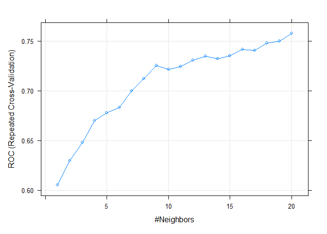

```r
plot(data2_knn_train)
```

```r
data2_knn_train$results$k = 9
```

### SVM

The main advantage of SVM algorithm is that we reduce the risk of overfitting. Moreover, the appropriate kernel function allows to solve any complex problem. However, it also has some disadvantages. Especially, it is difficult to tune proper hyper parameters, cost -C and gamma. We decided to go on with the parameters suggested by algorithm, sigma = 0.03044707 and C = 0.25.

```r
parametersC_sigma2 <-
  expand.grid(C = c(0.1,0.5,0.1),
              sigma = c(0.01,0.05,0.01))

data2_svm_train <-
  train(consumption_cocaine_last_month ~ .,
        data2,
        method = "svmRadial",
        metric = "ROC",
        trControl = ctrl_cv5)
        #tuneGrid = parametersC_sigma2)

data2_svm_train
```

```
## Support Vector Machines with Radial Basis Function Kernel
##
## 1500 samples
##    8 predictor
##    2 classes: 'No', 'Yes'
##
## No pre-processing
## Resampling: Cross-Validated (5 fold, repeated 3 times)
## Summary of sample sizes: 1199, 1200, 1201, 1200, 1200, 1199, ...
## Addtional sampling using up-sampling
##
## Resampling results across tuning parameters:
##
##   C     ROC        Sens       Spec
##   0.25  0.7819312  0.7800451  0.6586667
##   0.50  0.7666103  0.7960770  0.5956923
##   1.00  0.7579168  0.8205884  0.5375385
##
## Tuning parameter 'sigma' was held constant at a value of 0.03044707
## ROC was used to select the optimal model using the largest value.
## The final values used for the model were sigma = 0.03044707 and C = 0.25.
```

### Random Forest

Additionally, we decided to try new algorithm that we did not have during our classes which was random forest. This method has a couple of advantages that previous ones did not have. Firstly, it is known that this algorithm is popular due to its accuracy. And this is a main reason why we decided to try it out. We believed that our dataset need precise method because it is imbalanced. Moreover, this method also solves the problem of overfitting. The important issue in this algorithm is to select proper number of variables randomly sampled as of candidates for each split. We can notice on the graph below that number two variables are characterized with the highest ROC value.

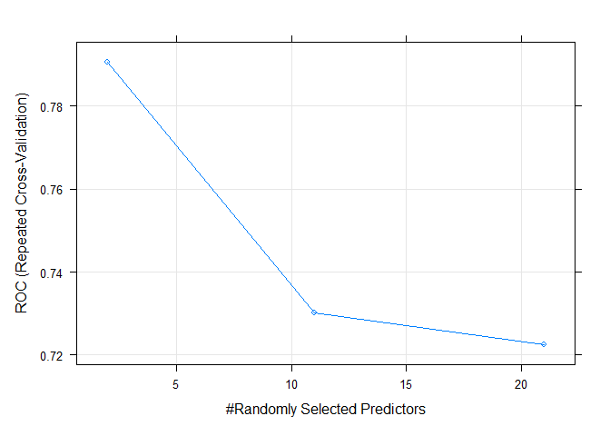

```r
data2_rf_train <-
  train(consumption_cocaine_last_month ~ .,
        data2,
        method = "rf",
        metric = "ROC",
        trControl = ctrl_cv5)

plot(data2_rf_train)
```

## Model Evaluation

In order to choose our final model we decided to run predictions on the whole dataset using all algorithms. We used parameters that were selected in our previous steps. We also decided to choose Balanced Accuracy as our final index to evaluate accuracy of our model.

```r
logit_fitted = predict(data2_logit_train1, data2)
logit_results = summary_binary_class(predicted_classes = logit_fitted,
                     real = data2$consumption_cocaine_last_month)

knn_fitted = predict(data2_knn_train, data2)
knn_results = summary_binary_class(predicted_classes = knn_fitted,
                     real = data2$consumption_cocaine_last_month)

svm_fitted = predict(data2_svm_train, data2)
svm_results = summary_binary_class(predicted_classes = svm_fitted,
                     real = data2$consumption_cocaine_last_month)

rf_fitted = predict(data2_rf_train, data2)
rf_results = summary_binary_class(predicted_classes = rf_fitted,
                     real = data2$consumption_cocaine_last_month)

balanced_accuracy  = matrix(1:4, nrow=1, ncol=4)

balanced_accuracy[1,1]=confusionMatrix(as.factor(logit_fitted), data2$consumption_cocaine_last_month)$byClass[11]
balanced_accuracy[1,2]=confusionMatrix(as.factor(knn_fitted), data2$consumption_cocaine_last_month)$byClass[11]
balanced_accuracy[1,3]=confusionMatrix(as.factor(svm_fitted), data2$consumption_cocaine_last_month)$byClass[11]
balanced_accuracy[1,4]=confusionMatrix(as.factor(rf_fitted), data2$consumption_cocaine_last_month)$byClass[11]

colnames(balanced_accuracy) = c("Logit","KNN","SVM","Random Forest")
rownames(balanced_accuracy) = c("Balanced Accuracy")
kable(balanced_accuracy)
```

|  | Logit | KNN | SVM | Random Forest |
| --- | --- | --- | --- | --- |
| Balanced Accuracy | 0.7685854 | 0.7515585 | 0.8160847 | 0.8303961 |

```r
print(paste0('The best algorithm for our dataset is ', colnames(balanced_accuracy)[apply(balanced_accuracy,1,which.max)],
             ' with the predicted Balanced Accuracy equals to ', round(balanced_accuracy[apply(balanced_accuracy,1,which.max)]*100,2),'%'))
```

```
## [1] "The best algorithm for our dataset is Random Forest with the predicted Balanced Accuracy equals to 83.04%"
```